# 1.transform (exercises)

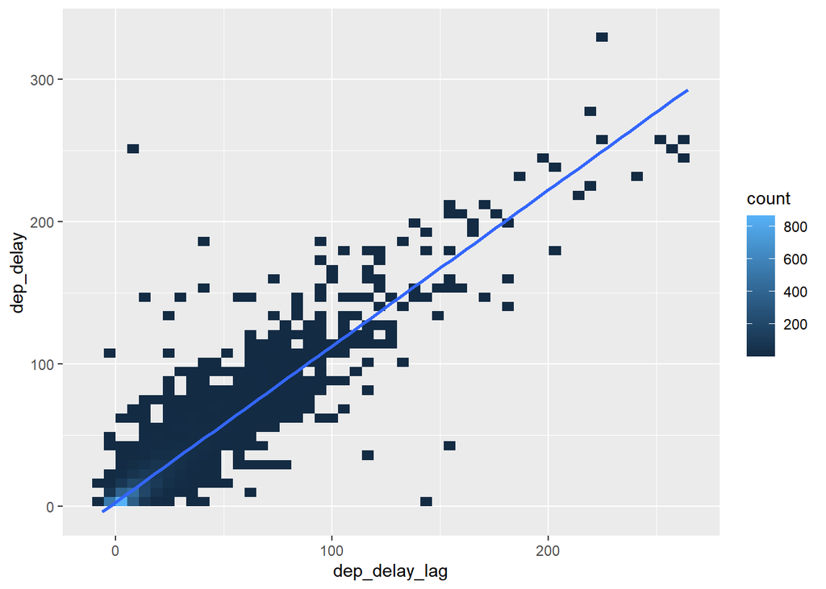

```r
flights_dep_lag |>
  ggplot(aes(x = dep_delay_lag, y = dep_delay)) +
  geom_bin2d(bins = 50) +
  stat_smooth(method = "lm", formula = "y~x", se = FALSE)
```

```r
rm(flights_dep_lag)
```

g) Look at each destination. Can you find flights that are suspiciously fast (i.e. flights that represent a potential data entry error)? Compute the air time of a flight relative to the shortest flight to that destination. Which flights were most delayed in the air?

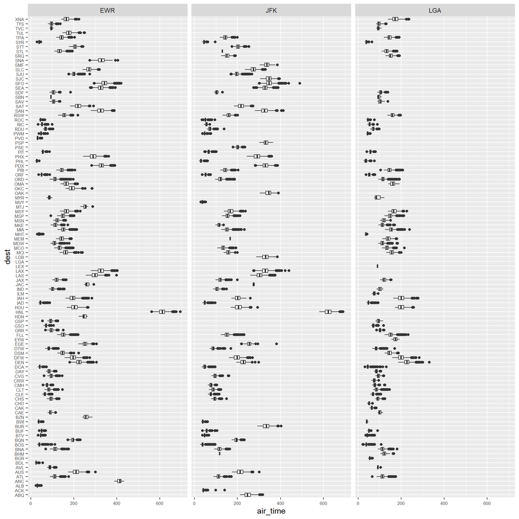

```r
flights |>
  ggplot(aes(x = air_time, y = dest)) +
  geom_boxplot() +
  facet_wrap(~origin, ncol=3) +
  theme(axis.text = element_text(size=6))
```

```r
flights |>
  #group by "origin" and "dest"
  group_by(origin, dest) |>
  mutate(
    #calculate Q25(air_time) per group
    at_Q25 = quantile(air_time, prob = 0.25, na.rm = TRUE),
    #calculate Q50(air_time) per group
    at_Q50 = quantile(air_time, prob = 0.50, na.rm = TRUE),
    #calculate Q75(air_time) per group
    at_Q75 = quantile(air_time, prob = 0.75, na.rm = TRUE),
    #calculate suspiciousness
    at_flg = air_time < at_Q25 - 2 * (at_Q75 - at_Q25)
  ) |>
  filter(at_flg) |>
  select(origin, dest, tailnum, air_time, at_Q25, at_Q50, at_Q75) |>
  arrange(desc(air_time))
```

```
## # A tibble: 17 × 7
## # Groups:   origin, dest [15]
##    origin dest  tailnum air_time at_Q25 at_Q50 at_Q75
##    <chr>  <chr> <chr>      <dbl>  <dbl>  <dbl>  <dbl>
##  1 JFK    SEA   N184DN       275    319    328    338
##  2 LGA    PBI   N956DL       105    138    145    153
##  3 EWR    MSP   N17196        93    142    149    158
##  4 EWR    BNA   N12567        70    106    113    121
##  5 LGA    ATL   N666DN        65    106    112    120
##  6 EWR    CVG   N11544        62     90     95    101
##  7 EWR    GSP   N14568        55     87     92     99
##  8 JFK    PIT   N718TW        48     63     66     70
##  9 JFK    BUF   N317JB        38     54     57     60
## 10 JFK    ORF   N662MQ        36     49     52     55
## 11 EWR    BTV   N13992        35     44     46     48
## 12 JFK    ROC   N323JB        35     49     51     54
## 13 EWR    RIC   N11189        35     50     53     56
## 14 EWR    BTV   N14562        34     44     46     48
## 15 EWR    SYR   N12924        30     37     39     40
## 16 LGA    BOS   N947UW        23     35     37     40
## 17 LGA    BOS   N947UW        21     35     37     40
```

```r
flights |>
  #group by "origin" and "dest"
  group_by(origin, dest) |>
  mutate(
    #calculate minimum air time per group
    at_min = min(air_time, na.rm = TRUE),
    #calculate air_time relative to minimum per group
    at_rel = air_time/at_min,
    #calculate the top most delayed flight per group
    at_flg = min_rank(desc(at_rel)) == 1
  ) |>
  filter(at_flg) |>
  select(origin, dest, tailnum, air_time, at_min, at_rel) |>
  arrange(desc(at_rel))
```

```
## # A tibble: 247 × 6
## # Groups:   origin, dest [223]
##    origin dest  tailnum air_time at_min at_rel
##    <chr>  <chr> <chr>      <dbl>  <dbl>  <dbl>
##  1 LGA    BOS   N967UW       107     21   5.10
##  2 LGA    DCA   N745VJ       131     32   4.09
##  3 JFK    ACK   N328JB       141     35   4.03
##  4 EWR    BOS   N37255       112     30   3.73
##  5 JFK    BOS   N3FKAA        96     26   3.69
##  6 JFK    PHL   N8932C        61     21   2.90
##  7 LGA    PHL   N755US        75     26   2.88
##  8 EWR    RIC   N13914       100     35   2.86
##  9 JFK    DCA   N813MQ        97     34   2.85
## 10 EWR    BDL   N13913        56     20   2.8
## # ℹ 237 more rows
```

h) Find all destinations that are flown by at least two carriers. Use those destinations to come up with a relative ranking of the carriers based on their performance for the same destination.

```r
flights |>
  #filter out NA values
  filter(!is.na(air_time)) |>
  #group by "dest"
  group_by(dest) |>
  #calculate number of observations per group
  mutate(n_carriers = n_distinct(carrier)) |>
  #filter for groups at least 2 observations
  filter(n_carriers > 1) |>
  #group by "carrier"
  group_by(dest, origin, carrier) |>
  #calculate performance
  summarize(at_mean = mean(air_time)) |>
  group_by(dest, origin) |>
  #calculate rank of performance per group
  mutate(at_rnk = min_rank(at_mean)) |>
  select(dest, origin, carrier, at_mean, at_rnk) |>
  arrange(dest, origin, at_rnk)
```

```
## # A tibble: 403 × 5
## # Groups:   dest, origin [189]
##    dest  origin carrier at_mean at_rnk
##    <chr> <chr>  <chr>     <dbl>  <int>
##  1 ATL   EWR    DL         111.      1
##  2 ATL   EWR    9E         111       2
##  3 ATL   EWR    UA         114.      3
##  4 ATL   EWR    EV         114.      4
##  5 ATL   JFK    DL         112.      1
##  6 ATL   JFK    EV         118       2
##  7 ATL   JFK    9E         121.      3
##  8 ATL   LGA    DL         113.      1
##  9 ATL   LGA    MQ         114.      2
## 10 ATL   LGA    FL         114.      3
## # ℹ 393 more rows
```

## 1.4. SUMMARY STATISTICS

a) Brainstorm at least 5 different summary statistics (center, location, spread) to describe the typical delay of flights to each destination. When is mean() useful? When is median() useful? When might you want to use something else? Should you use arrival delay or departure delay?

```r
flights |>
  mutate(
#   v = dep_delay                      #select dep_delay as variable in use
    v = arr_delay                      #select arr_delay as variable in use
  ) |>
  filter(v > 0) |>                     #filter in delayed flights
  group_by(dest, origin) |>            #group by "dest" and "origin"
  summarize(
    n = n(),                           #calculate number of obs. per group
    dd_ave = mean(v),                  #calculate mean per group (center)
    dd_Q50 = median(v),                #calculate median per group (center)
    dd_min = min(v),                   #calculate minimum per group (location)
    dd_max = max(v),                   #calculate maximum per group (location)
    dd_Q05 = quantile(v, prob = 0.05), #calculate Q05 per group (location)
    dd_Q25 = quantile(v, prob = 0.25), #calculate Q25 per group (location)
    dd_Q75 = quantile(v, prob = 0.75), #calculate Q25 per group (location)
    dd_Q95 = quantile(v, prob = 0.95), #calculate Q05 per group (location)
    dd_IQR = dd_Q75 - dd_Q25,          #calculate IQR per group (spread)
    dd_rng = dd_max - dd_min,          #calculate range per group (spread)
    dd_non = sum(v == 0)               #calculate number of zeros
  ) |>
  filter(n > 5) |>                     #filter for groups with observations > 5
  arrange(dest)                        #order by "dest"
```

```
## # A tibble: 211 × 14
## # Groups:   dest [100]
##    dest  origin     n dd_ave dd_Q50 dd_min dd_max dd_Q05 dd_Q25 dd_Q75 dd_Q95
##    <chr> <chr>  <int>  <dbl>  <dbl>  <dbl>  <dbl>  <dbl>  <dbl>  <dbl>  <dbl>
##  1 ABQ   JFK      107   41.9   31        1    153    3.3   14     56.5  124.
##  2 ACK   JFK      104   28.6   14.5      1    221    2      6     37.5   93.7
##  3 ALB   EWR      184   52.1   36.5      1    328    3     11     73.2  159.
##  4 ATL   EWR     2300   41.6   19        1    796    2      7     51    158
##  5 ATL   JFK      771   35.0   16        1    612    2      7     39    128.
##  6 ATL   LGA     4875   36.4   17        1    895    2      7     41    139
##  7 AUS   EWR      317   35.4   18        1    349    2      7     45    124.
##  8 AUS   JFK      666   43.1   25        1    328    2      9     56.8  145.
##  9 AVL   EWR      117   31.2   19        1    228    1      5     45     95.4
## 10 BDL   EWR      144   48.3   35.5      1    266    2     10.8   66.2  143.
## # ℹ 201 more rows
## # ℹ 3 more variables: dd_IQR <dbl>, dd_rng <dbl>, dd_non <int>
```

b) Which destinations show the greatest variation in air speed?

```r
flights |>
  #group by "dest"
  group_by(dest) |>
  summarize(
    #calculate variation of air time per group
    at_var = var(air_time, na.rm = TRUE),
    #calculate number of non-NA observations per group
    n = sum(!is.na(air_time))
  ) |>
  arrange(desc(at_var))
```

```
## # A tibble: 105 × 3
##    dest  at_var     n
##    <chr>  <dbl> <int>
##  1 HNL     470.   701
##  2 SNA     396.   812
##  3 OKC     373.   315
##  4 ABQ     372.   254
##  5 SAN     368.  2709
##  6 BUR     348.   370
##  7 PHX     345.  4606
##  8 LAX     335. 16026
##  9 AUS     332.  2411
## 10 LGB     332.   661
## # ℹ 95 more rows
```

c) Create a plot to further explore the adventures of EGE. Can you find any evidence that the airport moved locations? Can you find another variable that might explain the difference?

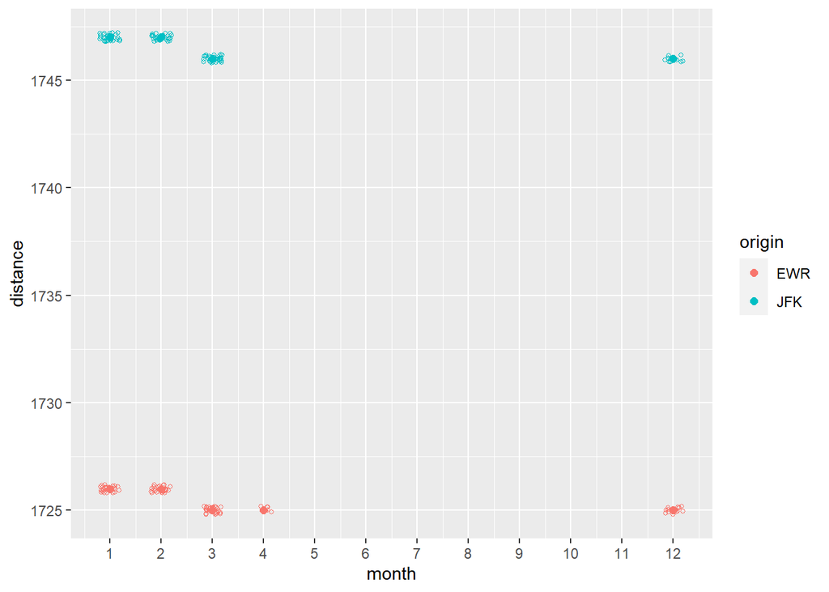

```r
flights |>
  filter(dest == "EGE") |>
  ggplot(aes(x = month, y = distance, color = origin)) +
  geom_point(size = 2) +
  geom_jitter(width = 0.2, height = 0.2, shape = 1, size = 1) +
  scale_x_continuous(breaks = 1:12)
```

# 2. FACTORS

[from https://r4ds.hadley.nz/factors.html]

[see https://jrnold.github.io/r4ds-exercise-solutions/factors.html]

[see https://mine-cetinkaya-rundel.github.io/r4ds-solutions/factors.html]

```r
library("tidyverse")
```

## 2.1. BASICS

[no exercises]